# Make a web application with Shiny!

Julin Maloof  
May 09, 2019

### QQplot

Before we go to Shiny, let me try to explain QQplots from the GWAS lab.

QQplots (quantile - quantile plots) are used to compare two distributions. Usually they are used to compare an observed distribution to a theoretical distribution.

Traditionally one compares “quantiles” of each data set.

### quantiles

**Quantiles** are another name for **percentiles**. They tell you the value of a data set at a particular quantile (percentile).

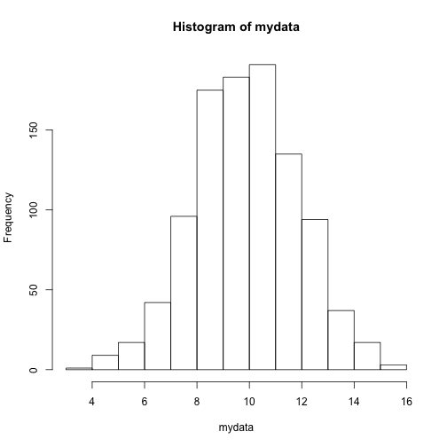

```r
mydata <- rnorm(n = 1000, mean = 10, sd = 2) #simulate a data set
hist(mydata)
```

### quantiles

```r
quantile(mydata, 0.95) # 95th pecentile
```

```
     95%
13.10132
```

```r
quantile(mydata, c(0.05, 0.25, 0.5, 0.75, 0.95)) %>% round(2)
```

```
   5%   25%   50%   75%   95%
 6.55  8.53  9.88 11.21 13.10
```

### quantiles

Simulate a second data set for comparison, different distribution:

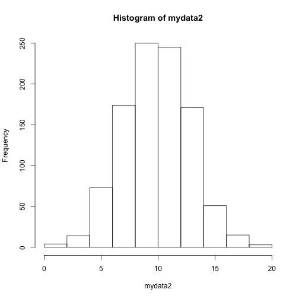

```r
mydata2 <- rnorm(n = 1000, mean = 10, sd = 3)
hist(mydata2)
```

### QQplot

Two compare these two distributions we plot the quantiles of each against one another

```r
mydata.quantiles <- quantile(mydata,seq(0,1,by=0.01))
head(mydata.quantiles)
```

```
      0%       1%       2%       3%       4%       5%
3.587054 5.021699 5.716399 6.161920 6.424502 6.548276
```

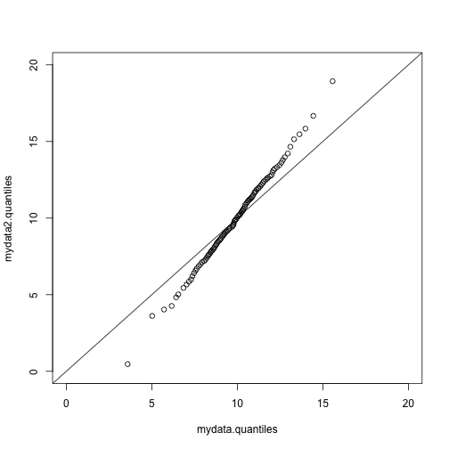

```r
mydata2.quantiles <- quantile(mydata2, seq(0,1,by=0.01))
plot(x=mydata.quantiles, y=mydata2.quantiles, ylim=c(0,20), xlim=c(0,20))
abline(a=0,b=1)
```

### QQplot and GWAS

In GWAS we expect that the vast majority of SNPs will not affect the phenotype (not be associated).

Population structure can cause many false positives. This results in there being more significant pvalues than expected. (aka p-value inflation). The QQpval plot allows us to visualize p-value inflation.

What is the expected distribution of p-values? Uniform (i.e. 0.05 quantile should be p=0.05, etc).

### QQpval plot (no pop structure correction)

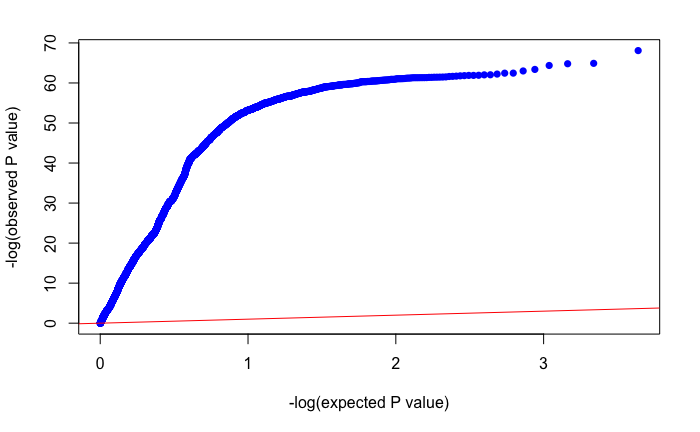

When we expect a p-value of 0.01, we are observing a p-value of?

What does this tell us about our observed p-values?

### QQpval plot (with pop structure correction)

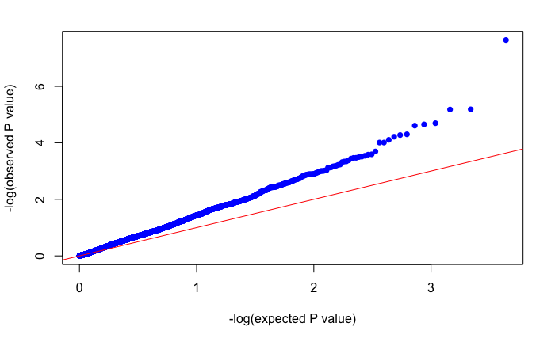

When we expect a p-value of 0.01, we are observing a p-value of?

What does this tell us about our observed p-values?

How does this compare to the uncorrected analysis?

### On to Shiny!

### Goal

- Make and deploy interactive web applications with [Shiny](http://shiny.rstudio.com/).
- Shiny allows you to display your R analysis on the web to anyone. For example:
- I used Shiny to write an app to visualize a [Markov Chain simulation of genetic drift](http://symposium.plb.ucdavis.edu:3838/MarkovDrift/).
- A student from a previous year of BIS180L is now working in my lab and is working up a [visualizer for QTL data and gene expression](http://symposium.plb.ucdavis.edu:3838/QTL-Visualization/).
- The Shiny website has plenty of [additional examples](http://shiny.rstudio.com/gallery/).

### Components of a Shiny App

A ShinyApp consists of two R scripts:

- **ui.R** This script controls the user interface (i.e. the design of the webpage, the input and the output).
- **server.R** This script does the work of performing any analysis, creating graphs, and creating tables

These two scripts must be saved together in a single directory. Each app much be saved in a different directory.

### Show scripts

### Moving information between `ui.R` and `server.R`

- information is passed via the `input` and `output` variables.

ui.R

```r
radioButtons("trait", #the input variable that the value will go into
             "Choose a trait to display:", #title
             c("Sepal.Length","Sepal.Width",
               "Petal.Length","Petal.Width") ) #options
```

server.R

```r
pl <- ggplot(data = iris,aes_string(x="Species",y=input$trait, fill="Species"))
```

`trait` in `ui.R` becomes `input$trait` in `server.R`

### Moving information between `ui.R` and `server.R`

ui.R

```r
mainPanel(plotOutput("boxPlot"))
```

server.R

```r
  output$boxPlot <- renderPlot({
        pl <- ggplot(data = iris,aes_string(x="Species", y=input$trait, fill="Species"))
        pl + geom_boxplot()
  })
```

### Keep your script fast

- Anything within a `renderNNN` statement will be run **every** time that the plot changes.
- So load data files and do one-time calculations at the **begining** of your server.R script.

```r
library(shiny)
library(ggplot2)

#load files and do one-time calculations here!

shinyServer(function(input, output) {
  output$boxPlot <- renderPlot({

  # Anything here gets re-run every time user input changes!
...
```

### Running on your computer

To try the app on your computer, save the above scripts in ui.R and server.R, respectively, in a directory for this app.

- Click on the `RunApp` Button in R studio
- OR from the R console:

```r
library(shiny)
runApp('PATH_TO_APP_DIRECTORY')
```

### Sharing

Now that we have our awesome application how do we share it?

Multiple options:

If you are sharing it with someone that uses R and has the shiny library installed, then you can just send it to them, they can download it, and run it as above.

### Sharing: GitHub

If you have it on GitHub and the person you want to share it with has R they can use:

```r
library(shiny)
runGitHub(repo = "HamiltonDemos",username = "jnmaloof", subdir = "BinomialDrift")
```

### Sharing: www.shinyapps.io

You can use Rstudio's **free** [shiny server](http://www.shinyapps.io/) Once you have signed up for an account and authenticated it a simple as:

```r
library(rsconnect)
rsconnect::deployApp('path/to/your/app')
```

You can see my version [here](https://jnmaloof.shinyapps.io/irisApp/)

### Sharing: set up your own server

If you are advanced you can [run your own server](http://www.rstudio.com/products/shiny/shiny-server/)

(I actually set up a server my lab–it isn't that hard)

### Teams

We will work in teams. Each team will produce and deploy a Shiny app that will be collectively graded.

| **Student 1** | **Student 2** | **Student 3** | **Repository** |
| --- | --- | --- | --- |
| Aditya | Chris |  | Shiny_Aditya.Chris |
| Alvin | Cole |  | Shiny_Alvin.Cole |
| Benny | Sankalp |  | Shiny_Benny.Sankalp |
| Chad | Rebecca |  | Shiny_Chad.Rebecca |
| Diane | Angus |  | Shiny_Diane.Angus |
| Elizabeth | Yimei |  | Shiny_Elizabeth.Yimei |
| Hanna | Bonnie |  | Shiny_Hanna.Bonnie |
| Hongtao | Carine |  | Shiny_Hongtao.Carine |
| Jana | Jonathan |  | Shiny_Jana.Jonathan |
| Jiaqi | Tina |  | Shiny_Jiaqi.Tina |
| Justin | Eric |  | Shiny_Justin.Eric |
| Karen | Amber |  | Shiny_Karen.Amber |

### Teams, continued

| **Student 1** | **Student 2** | **Student 3** | **Repository** |
| --- | --- | --- | --- |
| Kenzie | Nicole |  | Shiny_Kenzie.Nicole |
| King | Summer |  | Shiny_King.Summer |
| Krishna | Ria |  | Shiny_Krishna.Ria |
| Marcus | Picasso |  | Shiny_Marcus.Picasso |
| Michael | Amanda |  | Shiny_Michael.Amanda |
| Raymond | Danny |  | Shiny_Raymond.Danny |
| Richard | Natasha Ann |  | Shiny_Richard.Natasha |
| Samvardhini | Sina | Surbhi | Shiny_Samvardhini.Sina.Surbhi |
| Stevie | Yige |  | Shiny_Stevie.Yige |
| Tracy | Reema |  | Shiny_Tracy.Reema |
| Cameron | Karenjit |  | Shiny_Cameron.Karenjit |

### Assignment

Your team should work together to create and deploy a ShinyApp that plots some aspect of the data from the BLAST or RICE labs, or from the tomato measurements data set that you used for the ggplot tutorial, available [here](http://jnmaloof.github.io/BIS180L_web/data/Tomato.csv). The app should allow user input that modifies the plot in a useful way.

I have listed some ideas below, **but feel free to choose something else**

### BLAST ideas

- Interactive plot to explore different hypotheses for Exercise 10 from the R Intro lab.
  - The user could select which trait might affect the sequence length vs score relationship. The plot could be a scatter plot of score vs sequence length colored by the value of the user-selected variable. If you want to get fancy add a [slider-bar](http://shiny.rstudio.com/gallery/sliders.html) that allows the user to set the limits of the data ploted.
  - Or the plot could be a boxplot of score faceted by high and low sequence length and high and low values of the user-selected variable (you could split these by median length). Again you could add a [slider-bar](http://shiny.rstudio.com/gallery/sliders.html) that allows the user to set the split point for the graph facets.

### RICE data ideas

**You might want to limit the user input to 5 or 10 traits in the examples below, just to save yourself some typing and to keep the radio button list not too long**

- Interactive plot showing histograms or violin plots or boxplots of user-selected phenotypic data split by ancestral population assignment or region. You could also allow the user to choose whether it was a histogram or a violin plot, etc.
- scatter plot of any two traits (user chosen), colored by the values of a third (user chosen).
- If you want to get fancy in either of the above then you could use the [selectize](http://shiny.rstudio.com/gallery/selectize-examples.html) tool to allow the user to select from all of the possible phenotypes.

### Scoring (out of 20 points)

16 points for a functional, interactive web app deployed on shinyapps.io and pushed to GitHub.

+ 2 points for using two or more input types.  
+ 2 points for good annotation on the web page (a new user would understand what the app is about).  
- 2 points for each student that does not make at least 2 commits to the team repository.